# Which moving average function in R is fastest?

Dane Van Domelen

September 12, 2017

There are quite a few R functions/packages for calculating moving averages. The purpose of this article is to compare a bunch of them and see which is fastest.

Here are the 10 functions I’ll be looking at, in alphabetical order (Disclaimer: the **accelerometry** package is mine).

- *filter* in package **stats** (part of R install)
- *ma* in package **forecast**
- *movavg* in package **pracma**
- *movingaves* in package **accelerometry**
- *roll_mean* in package **RcppRoll**
- *rollapply* in package **zoo**
- *rollmean* in package **zoo**
- *runmean* in package **caTools**
- *runMean* in package **TTR**
- *SMA* in package **TTR**

First, here is the syntax for each function:

```r
# Sample 1,000 values from Poisson(3)
set.seed(1)
x <- rpois(n = 1000, lambda = 3)

# Calculate 5-unit moving average using each of the functions
width <- 5

y.filter <- filter(x = x, filter = rep(1, width)) / width
y.filter <- y.filter[! is.na(y.filter)]

library("forecast")
y.ma <- ma(x = x, order = width)
y.ma <- y.ma[! is.na(y.ma)]

library("pracma")
y.movavg <- movavg(x = x, n = width, type = "s")
y.movavg <- y.movavg[-c(1: (width - 1))]

library("accelerometry")
y.movingaves <- movingaves(x = x, window = width)

library("RcppRoll")
y.roll_mean <- roll_mean(x = x, n = width)

library("zoo")
y.rollapply <- rollapply(data = x, width = width, FUN = mean)
y.rollmean <- rollmean(x = x, k = width)

library("caTools")
y.runmean <- runmean(x = x, k = width, endrule = "trim")

library("TTR")
y.runMean <- runMean(x = x, n = width)
y.runMean <- y.runMean[! is.na(y.runMean)]

y.SMA <- SMA(x = x, n = width)
y.SMA <- y.SMA[! is.na(y.SMA)]
```

There were some minor differences among functions, i.e. whether they have extra NA’s in front or back, but I took care of that in the above code. All methods indeed give the same results:

```r
# Combine all of the moving average vectors into a matrix
y.all <- cbind(y.filter, y.ma, y.movavg, y.movingaves, y.roll_mean,
               y.rollapply, y.rollmean, y.runmean, y.runMean, y.SMA)

# Other than a small precision issue, all moving averages are the same
max(apply(y.all, 1, function(x) diff(range(x))))
```

```
## [1] 8.881784e-16
```

Let’s see which gives the fastest performance over 500 trials:

```r
library("rbenchmark")
(test1 <- benchmark(filter(x = x, filter = rep(1, width)) / width,
                    ma(x = x, order = width),
                    movavg(x = x, n = width, type = "s"),
                    movingaves(x = x, window = width),
                    roll_mean(x = x, n = width),
                    rollapply(data = x, width = width, FUN = mean),
                    rollmean(x = x, k = width),
                    runmean(x = x, k = width, endrule = "trim"),
                    runMean(x = x, n = width),
                    SMA(x = x, n = width),
                    replications = 500, order = "elapsed",
                    columns = c("test", "replications", "elapsed")))
```

```
##                                              test replications elapsed
## 4               movingaves(x = x, window = width)          500    0.02
## 5                     roll_mean(x = x, n = width)          500    0.02
## 2                        ma(x = x, order = width)          500    0.04
## 8     runmean(x = x, k = width, endrule = "trim")          500    0.05
## 1     filter(x = x, filter = rep(1, width))/width          500    0.06
## 9                       runMean(x = x, n = width)          500    0.20
## 10                          SMA(x = x, n = width)          500    0.20
## 7                      rollmean(x = x, k = width)          500    0.37
## 6  rollapply(data = x, width = width, FUN = mean)          500    0.56
## 3            movavg(x = x, n = width, type = "s")          500    3.53
```

I’ll do another quick test on a vector of non-integer values:

```r
# Sample 1,000 values from N(0, 1)
set.seed(1)
x <- rnorm(n = 1000)

(test2 <- benchmark(filter(x = x, filter = rep(1, width)) / width,
                    ma(x = x, order = width),
                    movavg(x = x, n = width, type = "s"),
                    movingaves(x = x, window = width),
                    roll_mean(x = x, n = width),
                    rollapply(data = x, width = width, FUN = mean),
                    rollmean(x = x, k = width),
                    runmean(x = x, k = width, endrule = "trim"),
                    runMean(x = x, n = width),
                    SMA(x = x, n = width),
                    replications = 500, order = "elapsed",
                    columns = c("test", "replications", "elapsed")))
```

```
##                                              test replications elapsed
## 4               movingaves(x = x, window = width)          500    0.01
## 5                     roll_mean(x = x, n = width)          500    0.02
## 2                        ma(x = x, order = width)          500    0.04
## 1     filter(x = x, filter = rep(1, width))/width          500    0.05
## 8     runmean(x = x, k = width, endrule = "trim")          500    0.07
## 10                          SMA(x = x, n = width)          500    0.19
## 9                       runMean(x = x, n = width)          500    0.21
## 7                      rollmean(x = x, k = width)          500    0.42
## 6  rollapply(data = x, width = width, FUN = mean)          500    0.50
## 3            movavg(x = x, n = width, type = "s")          500    3.50
```

It looks like *movavg*, *rollapply*, and *rollmean* are slower than the others, so let’s disqualify those three and continue to another scenario: a longer vector and a longer window length.

```r
# Sample 50,000 values from N(0, 1)
set.seed(1)
x <- rnorm(n = 50000)

width <- 500
(test3 <- benchmark(filter(x = x, filter = rep(1, width)) / width,
                    ma(x = x, order = width),
                    movingaves(x = x, window = width),
                    roll_mean(x = x, n = width),
                    runmean(x = x, k = width, endrule = "trim"),
                    runMean(x = x, n = width),
                    SMA(x = x, n = width),
                    replications = 500, order = "elapsed",
                    columns = c("test", "replications", "elapsed")))
```

```
##                                          test replications elapsed
## 3           movingaves(x = x, window = width)          500    0.22
## 5 runmean(x = x, k = width, endrule = "trim")          500    1.09
## 6                   runMean(x = x, n = width)          500    2.11
## 7                       SMA(x = x, n = width)          500    2.15
## 4                 roll_mean(x = x, n = width)          500   11.87
## 2                    ma(x = x, order = width)          500   45.40
## 1 filter(x = x, filter = rep(1, width))/width          500   45.71
```

Here *movingaves* looks like the clear winner. It’s interesting that *roll_mean* fell so far in this test. It seems to become progressively less efficient as the window size grows. Actually, let’s look directly at how window length affects speed for a fixed vector length.

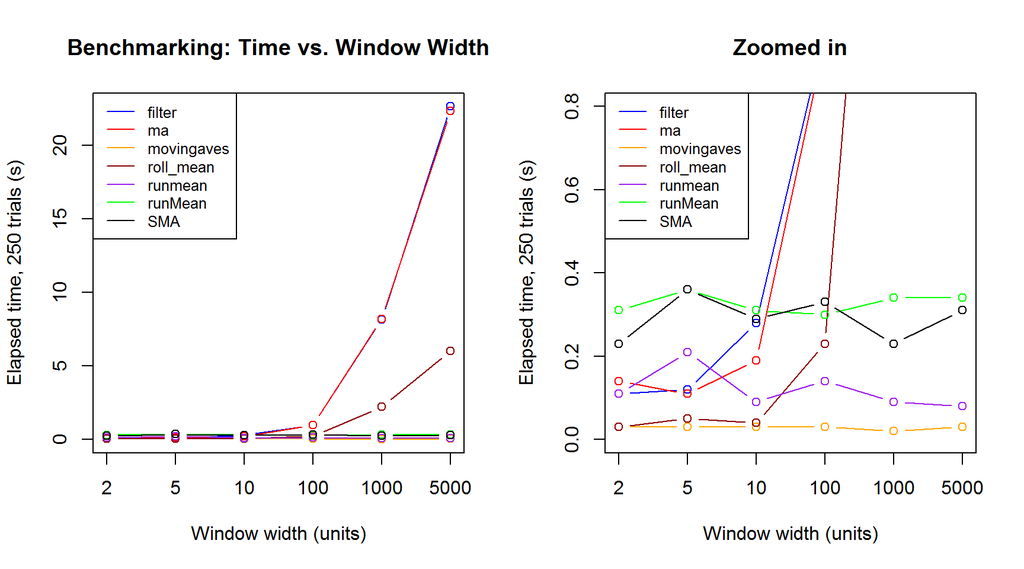

```r
# Look at effect of window size on speed of various functions
x <- rpois(n = 10000, lambda = 5)
width.vals <- c(2, 5, 10, 100, 1000, 5000)
benchmark.results <- matrix(NA, ncol = 7, nrow = length(width.vals))
for (ii in 1: length(width.vals)) {
  width.ii <- width.vals[ii]
  benchmark.results[ii, ] <-
    benchmark(filter(x = x, filter = rep(1, width.ii)) / width.ii,
              ma(x = x, order = width.ii),
              movingaves(x = x, window = width.ii),
              roll_mean(x = x, n = width.ii),
              runmean(x = x, k = width.ii, endrule = "trim"),
              runMean(x = x, n = width.ii),
              SMA(x = x, n = width.ii),
              replications = 250)$elapsed
}

# Create figure
cols <- c("blue", "red", "orange", "darkred", "purple", "green", "black")
par(mfrow = c(1, 2))
plot(benchmark.results[, 1],
     main = "Benchmarking: Time vs. Window Width",
     ylab = "Elapsed time, 250 trials (s)",
     xlab = "Window width (units)",
     ylim = c(0, max(benchmark.results)),
     type = "n",
     xaxt = "n")
axis(side = 1, at = 1: 6, labels = width.vals)
for (ii in 1: 7) {
  points(x = benchmark.results[, ii], type = "b", col = cols[ii])
}
legend("topleft", lty = 1, col = cols, cex = 0.8,
       legend = c("filter", "ma", "movingaves", "roll_mean", "runmean",
                  "runMean", "SMA"))

# Create zoomed-in version
plot(benchmark.results[, 1],
     main = "Zoomed in",
     ylab = "Elapsed time, 250 trials (s)",
     xlab = "Window width (units)",
     ylim = c(0, 0.8),
     type = "n",
     xaxt = "n")
axis(side = 1, at = 1: 6, labels = width.vals)
for (ii in 1: 7) {
  points(x = benchmark.results[, ii], type = "b", col = cols[ii])
}
legend("topleft", lty = 1, col = cols, cex = 0.8,
       legend = c("filter", "ma", "movingaves", "roll_mean", "runmean",
                  "runMean", "SMA"))
```

Note that the x-axis is not to scale; the results were easier to visualize this way. Overall, *movingaves* and *roll_mean* are similarly fast for relatively small window widths, but *movingaves* is easily the fastest when the window width gets larger.

For one last analysis, let’s see how the length of the vector affects the results, holding the window width fixed at 5 units. I’ll move back to 500 trials for these simulations, as they’re somewhat faster.

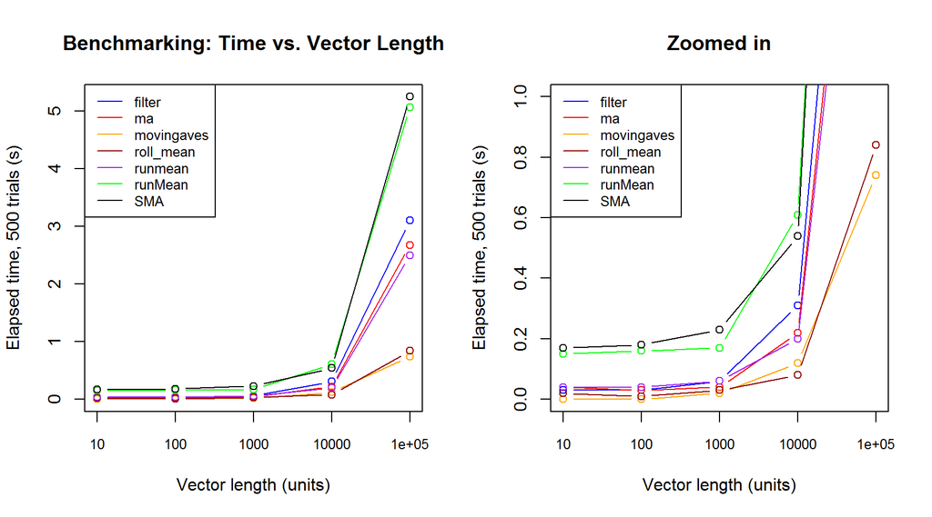

```r
# Look at effect of vector length on speed of various functions
length.vals <- c(10, 100, 1000, 10000, 100000)
width <- 5
benchmark.results <- matrix(NA, ncol = 7, nrow = length(length.vals))
for (ii in 1: length(length.vals)) {
  length.ii <- length.vals[ii]
  x <- rpois(n = length.ii, lambda = 5)
  benchmark.results[ii, ] <-  benchmark(filter(x = x, filter = rep(1, width)) / width,
                                        ma(x = x, order = width),
                                        movingaves(x = x, window = width),
                                        roll_mean(x = x, n = width),
                                        runmean(x = x, k = width, endrule = "trim"),
                                        runMean(x = x, n = width),
                                        SMA(x = x, n = width),
                                        replications = 500)$elapsed
}

# Create figure
cols <- c("blue", "red", "orange", "darkred", "purple", "green", "black")
par(mfrow = c(1, 2))
plot(benchmark.results[, 1],
     main = "Benchmarking: Time vs. Vector Length",
     ylab = "Elapsed time, 500 trials (s)",
     xlab = "Vector length (units)",
     ylim = c(0, max(benchmark.results)),
     type = "n",
     xaxt = "n")
axis(side = 1, at = 1: 5, labels = length.vals, cex.axis = 0.8)
for (ii in 1: 7) {
  points(x = benchmark.results[, ii], type = "b", col = cols[ii])
}
legend("topleft", lty = 1, col = cols, cex = 0.8,
       legend = c("filter", "ma", "movingaves", "roll_mean", "runmean",
                  "runMean", "SMA"))

# Create zoomed-in version
plot(benchmark.results[, 1],
     main = "Zoomed in",
     ylab = "Elapsed time, 500 trials (s)",
     xlab = "Vector length (units)",
     ylim = c(0, 1),
     type = "n",
     xaxt = "n")
axis(side = 1, at = 1: 5, labels = length.vals, cex.axis = 0.8)
for (ii in 1: 7) {
  points(x = benchmark.results[, ii], type = "b", col = cols[ii])
}
legend("topleft", lty = 1, col = cols, cex = 0.8,
       legend = c("filter", "ma", "movingaves", "roll_mean", "runmean",
                  "runMean", "SMA"))
```

Here, *movingaves* and *roll_mean* are again the two fastest, with *movingaves* achieving a small speed advantage as the vector length gets larger. It’s interesting to see that the other 5 functions really drop off in performance for large vectors.

In summary, surprise surprise, I’m going to recommend *movingaves* in my **accelerometry** package for calculating moving averages efficiently in R.